# NSW Redistribution 2020 Elector Data Checks

Melinda Lee, Hugh Burley, Jerry Chen, Jason Pallot

March 2020

# Introduction

The consulatancy Informed Decisions Pty Ltd (.Id) have provided the NSW Electoral Commission (NSWEC) with forecasts of the numbers of Electors within each of the Statistical Areas Level 1 (SA1) units for NSW for the period 2016-2029. An SA1 is an Australian Statistical Geography Standard (ASGS) unit produced by the Australian Bureau of Statistics (ABS) to collect, release and analyse geographically classified statistics.

The elector forecasts produced by .Id consist of an Excel data table providing 7-digit SA1 codes for each 2016 SA1 in NSW, with yearly expected enrolment from 2016-2029. Note - figures provided for the time period 2016-2019 are averages derived from historical enrolment data that was provided by the NSWEC to .Id. This was provided to .Id for the purpose of examining the historical share of electors to the eligible enrolable (18+ years) population.

The NSWEC Data Analytics and Geo-spatial Services (DAGS) team have conducted a sanity check of the data provided by .Id. This consisted of basic checks to quickly evaluate whether the data and results produced are rational. In the absence of a methodology report (to be provided by .Id at a later date) and modelling details, the data was examined for any anomalous changes in the predicted elector populations during the time period provided (2016-2029). For example, any sharp changes in enrolment between years were examined against existing knowledge of the area.

# Changes in Forecast Elector Projections between time periods

To examine the projections on the basis of locality, we aggregated the data up from SA1 to SA2 level, and calculated the difference across years (2016-2029). SA2s (Statistical Areas Level 2) are medium-sized general purpose areas built up from whole SA1s. As SA2s have generally been designed around whole gazetted suburbs or localities (eg. Homebush Bay - Silverwater), this provides a solid and meaningful basis to examine the data in a geographic context. Below is a table of all .Id elector projections, aggregated from SA1 to SA2 level (Table 1, excluding SA2s with a population < 2 in 2016). The columns labelled ‘enrolment change’ show the difference in projected electors between years.

| SA2 | Locality | Region | Area (km2) | Percent change | Enrolment Change 2016-20 | Enrolment Change 2016-24 | Enrolment Change 2020-29 | Enrolment Change 2016-29 | Standard deviation 2016-29 |
| --- | --- | --- | --- | --- | --- | --- | --- | --- | --- |
| 11007 | Braidwood | REGIONAL | 3418.4 | 0.087 | 322 | 381 | 124 | 446 | 34 |
| 11008 | Karabar | REGIONAL | 7 | 0.003 | 80 | 151 | 148 | 228 | 17.2 |
| 11009 | Queanbeyan | REGIONAL | 4.8 | 0.012 | 186 | 142 | -12 | 174 | 34.6 |
| 11010 | Queanbeyan - East | REGIONAL | 13 | 0.036 | 180 | 367 | 387 | 567 | 22.9 |
| 11011 | Queanbeyan Region | REGIONAL | 3054.4 | 0.197 | 2838 | 5356 | 5661 | 8499 | 78.8 |
| 11012 | Queanbeyan West - Jerrabomberra | REGIONAL | 13.7 | 0.016 | 105 | 92 | 44 | 149 | 31.5 |
| 11013 | Bombala | REGIONAL | 3989.4 | -0.027 | -15 | -30 | -39 | -54 | 14.5 |
| 11014 | Cooma | REGIONAL | 103.6 | 0.024 | 57 | 213 | 385 | 442 | 41.9 |
| 11015 | Cooma Region | REGIONAL | 6250.9 | 0.037 | 143 | 175 | 50 | 193 | 19.8 |
| 11016 | Jindabyne - Berridale | REGIONAL | 3939.5 | 0.084 | 474 | 648 | 335 | 809 | 51.2 |

[output cut: 561 more lines]

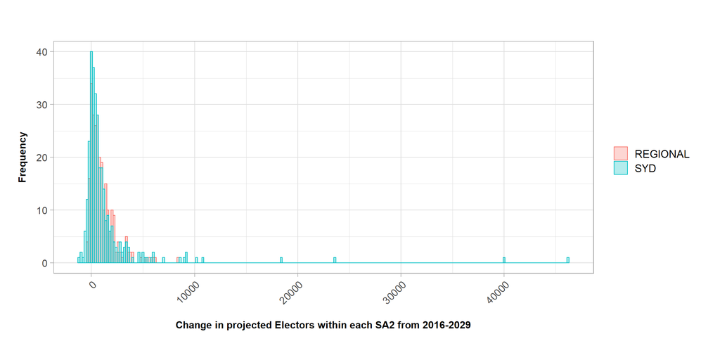

Fig 1). Distribution of change in elector projections

Most SA2s are projected to increase (469 out of 571, or 82%, Table 1), with the growth fairly evenly split between SA2s in both the greater Sydney Region and regional areas (51.8% vs 48.2% respectively). If we plot the difference in projected electors between years as a frequency distribution (i.e. counts of people projected to move in and out of each SA2, Fig 1), we can see that most of the projected changes are positive, and relatively small (median of +567, or +2.0% growth across 2016-29). Moreover, the distribution of predicted elector change is similar for Sydney and Regional SA2s (i.e. the medians of the distributions are similar, Fig 1). Interestingly, more Sydney SA2s are projected to decrease in elector population than regional SA2s (63.7% of the projected declines are in Sydney SA2s, vs. 36.3% of the declines being in regional SA2s).

# Elector population increase

For visual assessment of each SA2, we plotted the projected change in enrolment within SA2s between 2016-2029 as time-series. In the panels below, we plot a subset of the 571 SA2s analysed, divide up into three categories: SA2s which are projected to grow (Fig 2), shrink (Fig 3), and fluctuate (Fig 4). In Fig 2), we plot the nine SA2s which are projected to have largest increase in electors between 2016-2029 (note the bottom three plots for Fig 2 are Regional SA2s).

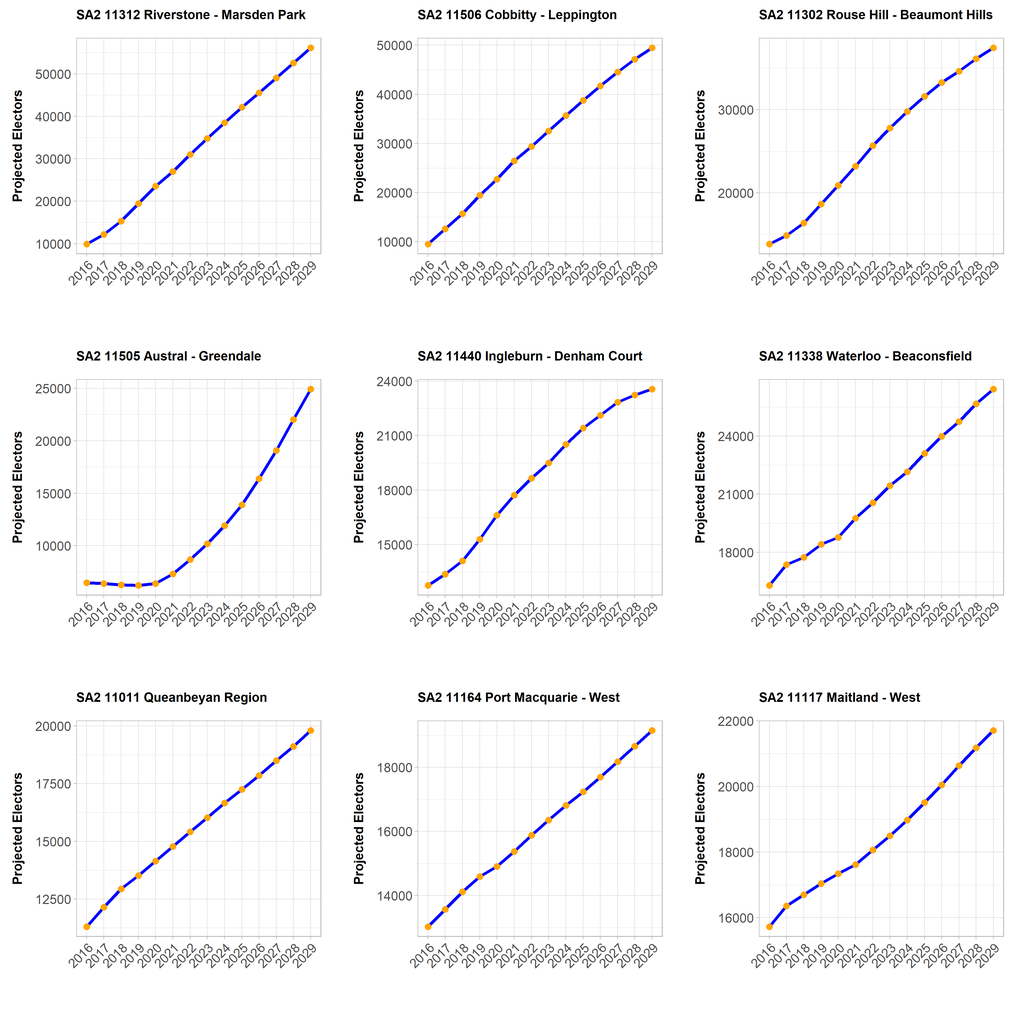

Fig 2). Change in Elector Population for Sydney and regional SA2s that are projected to increase between 2016-2029

# Elector population decrease

In Fig 3), we plot the nine SA2s which are predicted to have largest decreases in electors between 2016-2029 (note the bottom three plots for Fig 3 are Regional SA2s).

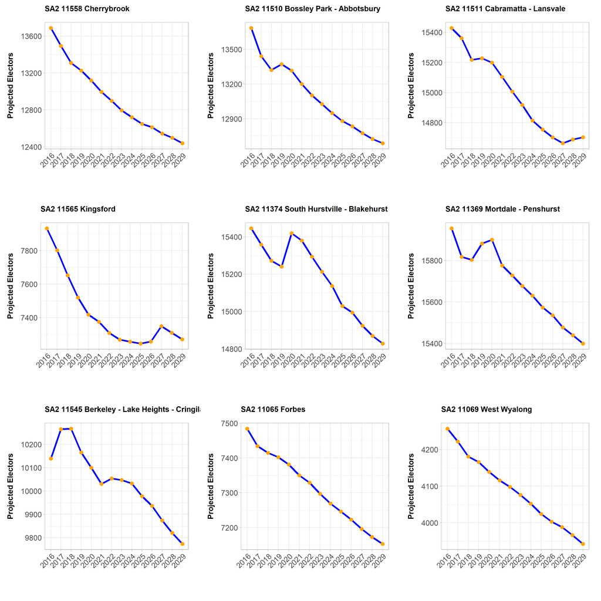

Fig 3). Change in Elector Population for Sydney and regional SA2s projected to decrease, 2016-2029

# Elector population fluctuation

Some predicted changes in the population are perfectly explicable, such as local development booms, or migration out of drought-affected areas (For example Forbes may have experienced a similar dynamic, Fig 3). However, there are areas where the predicted fluctuations are harder to interpret based on existing context of the area, or where knowledge of the area is limited (e.g. Figs 4a - 4d). Matthew Deacon from .Id has provided comments on each area, paraphrased below. In particular, he empahises that the rise and fall of electors in these areas is a very small share of the population in each area as a whole (conforming to the pattern evident across all areas, Table 1)

Accordign to .Id, there has been some residual development in Rooty Hill - Minchinbury, notably between the Greater Western Highway and John St, as well as Abraham St. The projections assume an increase of almost 300 dwellings in the period from 2016 to 2020 (Fig 4a). After 2020, only 240 additional dwellings are assumed over the 9 years to 2029. This leads to only a moderate increase in 18+ ERP to 2029, and when combined with a falling share of voters / 18+ pop, there is a minor decrease in voters. This area is unlikely to be a major focus for apartment development.

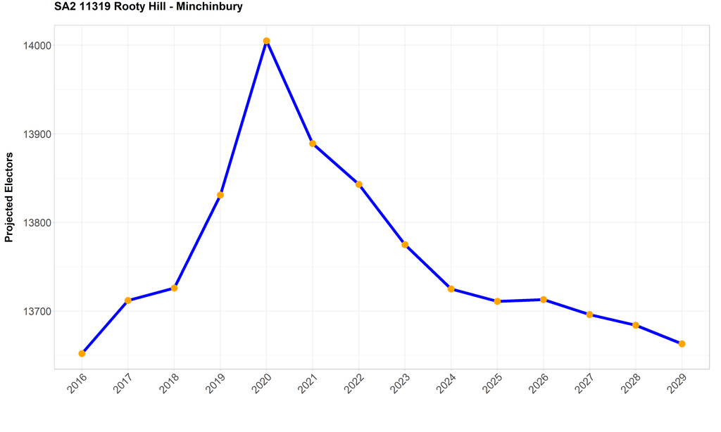

Fig 4a). Projected Change in Elector Population for Rooty Hill - Minchinbury SA2, 2016-2029

The predicted increase of voters in Gordon - Killara is heavily reliant on more residential development (Fig 4b). This is because the share of the population as voters is assumed to be falling over time (approximately 5% from 2020-2029).  
In 2019, the NSWEC data suggests that there were large increases in dwellings in SA1s 1140747, 1140752 and 1140753. From 2020 onwards, there is an assumed lull in development and then new sites are assumed to be developed from 2025 onwards. There is relatively little infill assumed, which reflects that most development will occur along the Pacific Highway / Railway corridor around the commercial centre. It is important to note the decrease in voters is small (-300), followed by a relatively small increase (+500). The area is one of high demand, but the area identified for intensification has already experienced substantial increases in apartments.

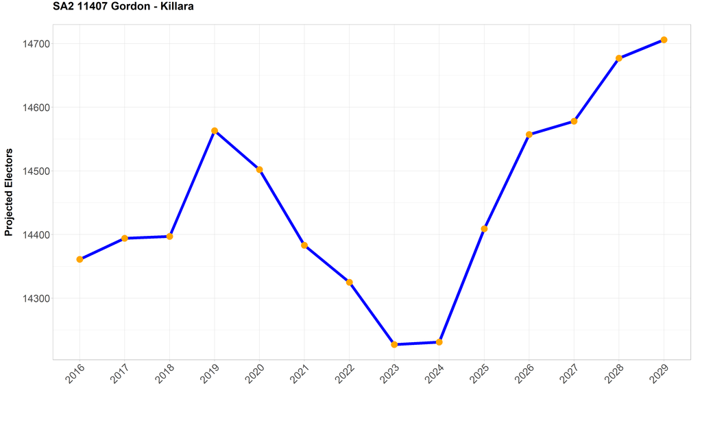

Fig 4b). Projected Change in Elector Population for Gordon - Killara SA2, 2016-2029

The projected changes in Canley Vale are driven by sporadic developments, rather than public housing. New dwellings in 2016 and 2017 means more voters, but like Gordon-Killara, the share of voters in the 18+ ERP is assumed to decrease. in 2021 and 2024, where little development is assumed, the elector population falls. Again, the population is rising and falling within a very small range (200 people, Fig 4c). Overall, the number of electors is expected to be fairly stable over the next ten years.

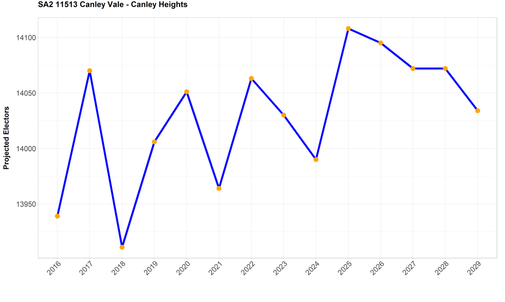

Fig 4c). Projected Change in Elector Population for Canley Vale - Canley Heights SA2, 2016-2029

Potts Point - Woolloomooloo has similarities to those areas described above, with moderate assumed dwelling increases from 2016-2020, followed by less development (Fig 4d). Like Gordon-Killara, this area is in high demand, thus if additional opportunities can be identified, there will be more population growth. However, the area is highly developed, and available sites are few and far between.

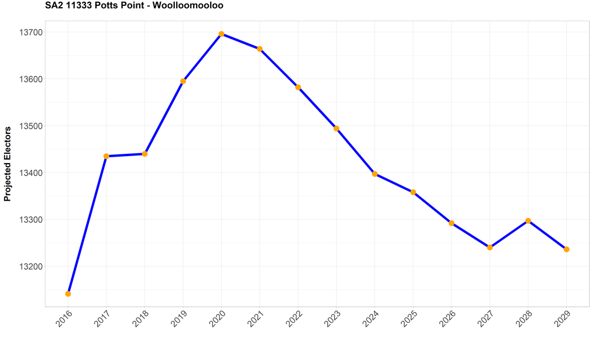

Fig 4d). Projected Change in Elector Population for Potts Point - Woolloomooloo SA2, 2016-2029

# Elector population fluctuation

The Projected Elector Poulation data provided by ID are assumed to be reliable, with the best available data and methods predicting different tracjecories for different regions based on their demographics (detials provided in the modelling methodology report). Nonetheless, we suggests running similar checks in future, given the mutual benefit to both the consultants and the NSWEC in understanding the strengths and limitations of their respective data and methods.